# Projet de Statistique Prévision : Wikipedia Traffic Forecast

## NGO Khoa Anh, Athéna Brisse, ISUP, M2 ISDS

# Table des matières

1. Introduction
2. Visualisation des données
3. Creation des nouvelles variables explicatives (Access, Agent et Site Web Source)
4. Trouver le language des pages
5. Creation le theme d'article
6. ARIMA sur le traffic des pages par rapport à language utilisée (Anglais, Allemand, Francais, Chinois)
7. Construction le modèle ARIMA optimal en utilisant Out-of-Time Cross validation
8. Prédiction avec XGBoost
9. Prediction avec Random Forest
10. Conclusion

### Bibliothèques

```python
import pandas as pd
import numpy as np
import matplotlib.pyplot as plt
import re
%matplotlib inline
from collections import Counter
from statsmodels.tsa.stattools import adfuller # adf test
from statsmodels.tsa.stattools import kpss #kpss test
from statsmodels.tsa.stattools import acf, pacf #acf, pacf
from statsmodels.graphics.tsaplots import plot_acf, plot_pacf #plot acf, plot pacf
import plotly.express as px #plot
import seaborn as sns
from statsmodels.tsa.arima.model import ARIMA #ARIMA
import tensorflow as tf
import torch
from transformers import pipeline
from sklearn.model_selection import cross_val_score
from sklearn.model_selection import GridSearchCV
from sklearn.model_selection import TimeSeriesSplit
from sklearn.preprocessing import StandardScaler
from sklearn.ensemble import RandomForestRegressor
from sklearn.linear_model import Ridge, RidgeCV, Lasso, LassoCV
from sklearn.pipeline import Pipeline
from sklearn.metrics import mean_squared_error, mean_absolute_error, r2_score


#Remove warning
import warnings
warnings.filterwarnings('ignore')
```

# Introduction

Prédire le trafic des pages de Wikipédia est une tâche utile pour comprendre comment les utilisateurs interagissent avec la plateforme et pour optimiser les performances et la disponibilité des serveurs de Wikipédia. Dans ce projet, nous visons à prédire le trafic sur les pages de Wikipedia en utilisant trois modèles d'apprentissage automatique différents : ARIMA, XGBoost, et Random Forest.

ARIMA (Autoregressive Integrated Moving Average) est un modèle populaire de prévision de séries temporelles qui est utilisé pour prédire les valeurs futures d'une série sur la base de ses valeurs passées. XGBoost est un modèle d'arbre de boosting à gradient qui est largement utilisé pour les tâches de classification et de régression. Random Forest est une méthode d'apprentissage d'ensemble qui combine les prédictions de plusieurs modèles d'arbres décisionnels pour améliorer la précision globale des prédictions.

Nous utiliserons un ensemble de données sur le trafic historique des pages Wikipédia pour former et évaluer les performances de ces trois modèles. L'objectif de ce projet est d'identifier le modèle le plus efficace pour prédire le trafic de sites web sur les pages de Wikipedia et de fournir des informations sur les facteurs qui influencent le trafic de sites web sur la plate-forme.

J'espère que cela vous donne un bon aperçu de notre projet. Dans les sections suivantes, nous décrirons plus en détail le jeu de données, les étapes de prééprocessing et le dispositif expérimental mis en place.

# Visualisation des données

```python
train = pd.read_csv('train_2.csv')
print("Shape des données:",train.shape)
```

```
Shape des données: (145063, 804)
```

```python
train.head(2)
```

|  | Page | 2015-07-01 | 2015-07-02 | 2015-07-03 | 2015-07-04 | 2015-07-05 | 2015-07-06 | 2015-07-07 | 2015-07-08 | 2015-07-09 | ... | 2017-09-01 | 2017-09-02 | 2017-09-03 | 2017-09-04 | 2017-09-05 | 2017-09-06 | 2017-09-07 | 2017-09-08 | 2017-09-09 | 2017-09-10 |
| --- | --- | --- | --- | --- | --- | --- | --- | --- | --- | --- | --- | --- | --- | --- | --- | --- | --- | --- | --- | --- | --- |
| 0 | 2NE1_zh.wikipedia.org_all-access_spider | 18.0 | 11.0 | 5.0 | 13.0 | 14.0 | 9.0 | 9.0 | 22.0 | 26.0 | ... | 19.0 | 33.0 | 33.0 | 18.0 | 16.0 | 27.0 | 29.0 | 23.0 | 54.0 | 38.0 |
| 1 | 2PM_zh.wikipedia.org_all-access_spider | 11.0 | 14.0 | 15.0 | 18.0 | 11.0 | 13.0 | 22.0 | 11.0 | 10.0 | ... | 32.0 | 30.0 | 11.0 | 19.0 | 54.0 | 25.0 | 26.0 | 23.0 | 13.0 | 81.0 |

2 rows × 804 columns

Après visualisation des premières lignes du dataset, on a bien 145063 pages Wikipedia avec ses trafics pendant 803 jours, du 01/07/2015 au 10/09/2017.

### **Variables NaN :**

En examinant plus précisément, on constate qu'il y a des variables "anormales" : des valeurs NaN. Regardons de plus près ces données atypiques : combien il y en a, leur composition,...

```python
print("Nombre des données NA par jour:\n", train.isna().sum(), '\n')
print("Nombre des données NA au total:",train.isna().sum().sum())
```

```
Nombre des données NA par jour:
 Page              0
2015-07-01    20740
2015-07-02    20816
2015-07-03    20544
2015-07-04    20654
              ...
2017-09-06     1775
2017-09-07     3467
2017-09-08     1061
2017-09-09     3332
2017-09-10     5578
Length: 804, dtype: int64

Nombre des données NA au total: 7027348
```

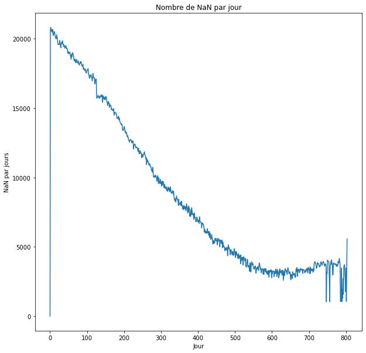

```python
jours = [r for r in range(train.isna().sum().shape[0])]

fig = plt.figure(1,figsize=[10,10])
plt.ylabel('NaN par jours')
plt.xlabel('Jour')
plt.title('Nombre de NaN par jour')

plt.plot(jours,train.isna().sum())
plt.show()
```

Il y a 7027348 valeurs NaN a total, et beaucoup plus au début de la collecte des données. Il faudra garder cela en têtes pour faire assurer une rigueur dans nos prédictions.

```python
print("Pourcentage des données NA:",round(train.isna().sum().sum()*100/(len(train)*len(train.columns)),2), "%.")
```

```
Pourcentage des données NA: 6.03 %.
```

Malgré cela, les NaN ne représentent que 6.03% de nos données, ce qui permet toutefois de faire des travaux intéressants et proches de la réalité. On efface tous les NAN

```python
train =train.dropna()
```

```python
train[train['Page'].str.contains("wikimedia")]
```

|  | Page | 2015-07-01 | 2015-07-02 | 2015-07-03 | 2015-07-04 | 2015-07-05 | 2015-07-06 | 2015-07-07 | 2015-07-08 | 2015-07-09 | ... | 2017-09-01 | 2017-09-02 | 2017-09-03 | 2017-09-04 | 2017-09-05 | 2017-09-06 | 2017-09-07 | 2017-09-08 | 2017-09-09 | 2017-09-10 |
| --- | --- | --- | --- | --- | --- | --- | --- | --- | --- | --- | --- | --- | --- | --- | --- | --- | --- | --- | --- | --- | --- |
| 13332 | Accueil_commons.wikimedia.org_all-access_spider | 55.0 | 48.0 | 44.0 | 35.0 | 46.0 | 41.0 | 32.0 | 43.0 | 40.0 | ... | 168.0 | 123.0 | 58.0 | 72.0 | 146.0 | 3232.0 | 5853.0 | 46.0 | 48.0 | 52.0 |
| 13333 | Atlas_of_Asia_commons.wikimedia.org_all-access... | 5.0 | 3.0 | 4.0 | 6.0 | 3.0 | 1.0 | 5.0 | 6.0 | 6.0 | ... | 22.0 | 26.0 | 28.0 | 25.0 | 22.0 | 20.0 | 23.0 | 21.0 | 23.0 | 21.0 |
| 13334 | Atlas_of_Europe_commons.wikimedia.org_all-acce... | 4.0 | 6.0 | 9.0 | 7.0 | 6.0 | 4.0 | 5.0 | 6.0 | 13.0 | ... | 31.0 | 30.0 | 27.0 | 21.0 | 33.0 | 40.0 | 39.0 | 21.0 | 33.0 | 35.0 |
| 13335 | Atlas_of_World_War_II_commons.wikimedia.org_al... | 5.0 | 2.0 | 6.0 | 6.0 | 8.0 | 11.0 | 5.0 | 5.0 | 6.0 | ... | 9.0 | 15.0 | 9.0 | 11.0 | 11.0 | 7.0 | 13.0 | 5.0 | 9.0 | 13.0 |
| 13336 | Atlas_of_colonialism_commons.wikimedia.org_all... | 8.0 | 6.0 | 15.0 | 5.0 | 5.0 | 9.0 | 10.0 | 3.0 | 9.0 | ... | 27.0 | 19.0 | 29.0 | 48.0 | 27.0 | 23.0 | 20.0 | 28.0 | 27.0 | 30.0 |
| ... | ... | ... | ... | ... | ... | ... | ... | ... | ... | ... | ... | ... | ... | ... | ... | ... | ... | ... | ... | ... | ... |
| 82908 | Category:Uploaded_with_VicuñaUploader_commons.... | 13.0 | 13.0 | 14.0 | 15.0 | 9.0 | 11.0 | 13.0 | 7.0 | 13.0 | ... | 399.0 | 264.0 | 168.0 | 140.0 | 44.0 | 45.0 | 101.0 | 79.0 | 44.0 | 131.0 |
| 82910 | Početna_strana_commons.wikimedia.org_desktop_a... | 69.0 | 86.0 | 78.0 | 63.0 | 58.0 | 65.0 | 97.0 | 95.0 | 77.0 | ... | 137.0 | 118.0 | 121.0 | 125.0 | 153.0 | 1660.0 | 5512.0 | 144.0 | 113.0 | 122.0 |
| 82911 | Commons:Portale_Comunità_commons.wikimedia.org... | 71.0 | 61.0 | 60.0 | 56.0 | 50.0 | 60.0 | 72.0 | 73.0 | 57.0 | ... | 55.0 | 43.0 | 32.0 | 49.0 | 81.0 | 62.0 | 58.0 | 63.0 | 52.0 | 52.0 |
| 82912 | Commons:Média_du_jour_commons.wikimedia.org_de... | 12.0 | 12.0 | 17.0 | 17.0 | 8.0 | 16.0 | 21.0 | 15.0 | 12.0 | ... | 15.0 | 6.0 | 14.0 | 14.0 | 19.0 | 18.0 | 12.0 | 23.0 | 11.0 | 15.0 |
| 82914 | Pàgina_principal_commons.wikimedia.org_desktop... | 140.0 | 137.0 | 131.0 | 115.0 | 83.0 | 132.0 | 176.0 | 162.0 | 138.0 | ... | 217.0 | 200.0 | 173.0 | 247.0 | 237.0 | 1733.0 | 5638.0 | 246.0 | 182.0 | 181.0 |

5120 rows × 804 columns

```python
train[train['Page'].str.contains("mediawiki")]
```

|  | Page | 2015-07-01 | 2015-07-02 | 2015-07-03 | 2015-07-04 | 2015-07-05 | 2015-07-06 | 2015-07-07 | 2015-07-08 | 2015-07-09 | ... | 2017-09-01 | 2017-09-02 | 2017-09-03 | 2017-09-04 | 2017-09-05 | 2017-09-06 | 2017-09-07 | 2017-09-08 | 2017-09-09 | 2017-09-10 |
| --- | --- | --- | --- | --- | --- | --- | --- | --- | --- | --- | --- | --- | --- | --- | --- | --- | --- | --- | --- | --- | --- |
| 19614 | API_www.mediawiki.org_all-access_all-agents | 528.0 | 587.0 | 634.0 | 483.0 | 510.0 | 559.0 | 625.0 | 594.0 | 565.0 | ... | 458.0 | 325.0 | 330.0 | 462.0 | 529.0 | 439.0 | 459.0 | 439.0 | 302.0 | 274.0 |
| 19615 | API:Account_creation_www.mediawiki.org_all-acc... | 37.0 | 38.0 | 46.0 | 41.0 | 79.0 | 91.0 | 100.0 | 54.0 | 43.0 | ... | 32.0 | 25.0 | 24.0 | 44.0 | 43.0 | 35.0 | 37.0 | 37.0 | 33.0 | 25.0 |
| 19616 | API:Allimages_www.mediawiki.org_all-access_all... | 19.0 | 31.0 | 19.0 | 10.0 | 32.0 | 26.0 | 29.0 | 23.0 | 21.0 | ... | 6.0 | 11.0 | 10.0 | 14.0 | 9.0 | 12.0 | 15.0 | 13.0 | 14.0 | 4.0 |
| 19617 | API:Allpages_www.mediawiki.org_all-access_all-... | 32.0 | 29.0 | 14.0 | 15.0 | 23.0 | 41.0 | 39.0 | 27.0 | 35.0 | ... | 15.0 | 12.0 | 7.0 | 19.0 | 22.0 | 21.0 | 19.0 | 20.0 | 10.0 | 11.0 |
| 19618 | API:Backlinks_www.mediawiki.org_all-access_all... | 29.0 | 16.0 | 15.0 | 19.0 | 18.0 | 20.0 | 19.0 | 21.0 | 23.0 | ... | 13.0 | 12.0 | 14.0 | 19.0 | 14.0 | 22.0 | 13.0 | 10.0 | 8.0 | 10.0 |
| ... | ... | ... | ... | ... | ... | ... | ... | ... | ... | ... | ... | ... | ... | ... | ... | ... | ... | ... | ... | ... | ... |
| 84707 | Wikimedia_Apps/Team_www.mediawiki.org_all-acce... | 4.0 | 4.0 | 3.0 | 3.0 | 9.0 | 8.0 | 3.0 | 1.0 | 1.0 | ... | 2.0 | 3.0 | 1.0 | 3.0 | 2.0 | 4.0 | 8.0 | 4.0 | 8.0 | 1.0 |
| 84709 | Wikimedia_Apps/iOS_FAQ_www.mediawiki.org_all-a... | 0.0 | 0.0 | 2.0 | 0.0 | 0.0 | 1.0 | 0.0 | 1.0 | 0.0 | ... | 2.0 | 2.0 | 5.0 | 1.0 | 1.0 | 5.0 | 4.0 | 2.0 | 3.0 | 2.0 |
| 84723 | Wikimedia_Language_engineering_www.mediawiki.o... | 29.0 | 73.0 | 32.0 | 44.0 | 54.0 | 33.0 | 38.0 | 12.0 | 10.0 | ... | 6.0 | 5.0 | 6.0 | 6.0 | 9.0 | 4.0 | 7.0 | 11.0 | 12.0 | 5.0 |
| 84727 | Wikipedia_Zero_www.mediawiki.org_all-access_sp... | 11.0 | 12.0 | 14.0 | 7.0 | 9.0 | 13.0 | 9.0 | 6.0 | 13.0 | ... | 4.0 | 2.0 | 5.0 | 4.0 | 5.0 | 10.0 | 6.0 | 7.0 | 6.0 | 4.0 |
| 84729 | Zürich_Hackathon_2014_www.mediawiki.org_all-ac... | 3.0 | 19.0 | 19.0 | 30.0 | 21.0 | 24.0 | 17.0 | 178.0 | 40.0 | ... | 10.0 | 4.0 | 8.0 | 7.0 | 5.0 | 8.0 | 6.0 | 6.0 | 5.0 | 6.0 |

3636 rows × 804 columns

Regardons de plus près l'intitulé d'une page : "2NE1_zh.wikipedia.org_all-access_spider"

On peut voir que le nom de la page contient des informations importantes pour comprendre la distribution des données :

- le **site Web source** de cette page ainsi que des informations sur la langue (par exemple "wikipedia" mais ce peut aussi être "wikimedia" ou "mediawiki", qui appartiennent également à l'ensemble des articles wikipedia, mais d'un autre type)
- le **type d'accès** par lequel les articles ont été consultés (mobile-web, desktop, all-access)
- l'**agent** par lequel les articles ont été consultés (spider, all-agents) Nous pouvons créer de nouvelles caractéristiques pour cette page en extrayant les informations mentionnées ci-dessus du nom de la page.

# Creer des nouvelles variables explicatives (Access, Agent et Site Web Source)

##### On split l'intitulé de chaque page pour obtenir l'acces, l'agent et le site web source

```python
page_acc_agent = pd.DataFrame([i.split("_")[-3:] for i in train["Page"]])
page_acc_agent.columns = ["Media type", "Access", "Agent"]
```

```python
page_acc_agent = pd.DataFrame([i.split("_")[-3:] for i in train["Page"]])
page_acc_agent.columns = ["Media type", "Access", "Agent"]
page_acc_agent.loc[page_acc_agent["Media type"].str.contains("wikipedia"), 'Media type'] = "wikipedia"
page_acc_agent.loc[page_acc_agent["Media type"].str.contains("wikimedia"), 'Media type'] = "wikimedia"
page_acc_agent.loc[page_acc_agent["Media type"].str.contains("mediawiki"), 'Media type'] = "mediawiki"
page_acc_agent
```

|  | Media type | Access | Agent |
| --- | --- | --- | --- |
| 0 | wikipedia | all-access | spider |
| 1 | wikipedia | all-access | spider |
| 2 | wikipedia | all-access | spider |
| 3 | wikipedia | all-access | spider |
| 4 | wikipedia | all-access | spider |
| ... | ... | ... | ... |
| 115079 | wikipedia | all-access | spider |
| 115080 | wikipedia | all-access | spider |
| 115081 | wikipedia | all-access | spider |
| 115082 | wikipedia | all-access | spider |
| 115083 | wikipedia | all-access | spider |

115084 rows × 3 columns

```python
# Ajouter dans nos donnes
train['Access']=page_acc_agent['Access']
train['Agent'] = page_acc_agent['Agent']
train['Media type'] = page_acc_agent['Media type']
train.head(2)
```

|  | Page | 2015-07-01 | 2015-07-02 | 2015-07-03 | 2015-07-04 | 2015-07-05 | 2015-07-06 | 2015-07-07 | 2015-07-08 | 2015-07-09 | ... | 2017-09-04 | 2017-09-05 | 2017-09-06 | 2017-09-07 | 2017-09-08 | 2017-09-09 | 2017-09-10 | Access | Agent | Media type |
| --- | --- | --- | --- | --- | --- | --- | --- | --- | --- | --- | --- | --- | --- | --- | --- | --- | --- | --- | --- | --- | --- |
| 0 | 2NE1_zh.wikipedia.org_all-access_spider | 18.0 | 11.0 | 5.0 | 13.0 | 14.0 | 9.0 | 9.0 | 22.0 | 26.0 | ... | 18.0 | 16.0 | 27.0 | 29.0 | 23.0 | 54.0 | 38.0 | all-access | spider | wikipedia |
| 1 | 2PM_zh.wikipedia.org_all-access_spider | 11.0 | 14.0 | 15.0 | 18.0 | 11.0 | 13.0 | 22.0 | 11.0 | 10.0 | ... | 19.0 | 54.0 | 25.0 | 26.0 | 23.0 | 13.0 | 81.0 | all-access | spider | wikipedia |

2 rows × 807 columns

### View Count (Access)

Il existe trois sources principales à partir desquelles ces pages Web sont accessibles, à savoir

- La plateforme All Access
- Plate-forme web mobile
- Plate-forme de bureau

```python
access_names = ["all-access", "desktop","mobile-web"]
count = [train["Access"].value_counts().sort_index()[0],train["Access"].value_counts().sort_index()[1],train["Access"].value_counts().sort_index()[2]]

# Accuracy
fig = px.bar(x=access_names, y=count, title="Traffic par rapport de type d'access", labels={'x': 'Type access', 'y':'Count'},color=access_names)
fig.show()
```

[interactive chart not shown]

D'après les diagrammes à barres ci-dessus, nous pouvons voir que le trafic est plus important pour les pages dont la catégorie d'accès est tout accès. Les deux autres catégories présentent comparativement moins de trafic. De même, le trafic sur le Web mobile est légèrement supérieur à celui sur le Web de bureau.

### View Count (Agent)

Il existe 2 sources principales d'agents, ce sont:

- spider
- all-agents

```python
agent_names = ["all-agents", "spider"]
count = [train["Agent"].value_counts().sort_index()[0],train["Agent"].value_counts().sort_index()[1]]

# Accuracy
fig = px.bar(x=agent_names, y=count, title="Traffic par rapport de type d'agent", labels={'x': 'Type agent', 'y':'Count'},color=agent_names)
fig.show()
```

[interactive chart not shown]

On trouve que le trafic est plus important pour les pages dont l'agent est tout agent

### View Media type

```python
media_types_names = ["wikipedia", "wikimedia", "mediawiki"]
count = [train["Media type"].value_counts().sort_index()[0],train["Media type"].value_counts().sort_index()[1], train["Media type"].value_counts().sort_index()[2]]

# Accuracy
fig = px.bar(x=media_types_names, y=count, title="Traffic par rapport au type de media", labels={'x': 'Media type', 'y':'Count'},color=media_types_names)
fig.show()
```

[interactive chart not shown]

La Wikimedia Foundation est une organisation à but non lucratif qui soutient et gère Wikipédia, ainsi qu'un certain nombre d'autres projets de connaissances libres, notamment Wiktionary, Wikibooks et Wikinews. La fondation se consacre à la promotion de la croissance, du développement et de la distribution de contenus libres et multilingues, et à la mise à disposition gratuite de l'intégralité du contenu de ces projets au public.

MediaWiki est le logiciel qui alimente Wikipédia et les autres projets de la fondation Wikimedia. Il s'agit d'une plateforme logicielle libre et gratuite utilisée pour l'édition collaborative de sites Web. MediaWiki est écrit dans le langage de programmation PHP et utilise une base de données, telle que MySQL, pour stocker le contenu et la configuration. Il a été développé à l'origine pour Wikipédia, mais a depuis été utilisé par un large éventail d'autres sites Web et organisations.

# Trouver le language des pages

```python
def trouver_language(page):
    res = re.search('[a-z][a-z].wikipedia.org',page)
    if res:
        return res[0][0:2]
    return 'na'

train['Language'] = train.Page.map(trouver_language)
train["Language"].value_counts().sort_index()
```

```
de    16145
en    16680
es    12773
fr    15760
ja    18379
na     8756
ru    13432
zh    13159
Name: Language, dtype: int64
```

```python
lang = ["de","en","es","fr","ja","na","ru","zh"]
count = [train["Language"].value_counts().sort_index()[0],train["Language"].value_counts().sort_index()[1],
         train["Language"].value_counts().sort_index()[2],train["Language"].value_counts().sort_index()[3],
         train["Language"].value_counts().sort_index()[4],train["Language"].value_counts().sort_index()[5],
         train["Language"].value_counts().sort_index()[6],train["Language"].value_counts().sort_index()[7]]

# Accuracy
fig = px.bar(x=lang, y=count, title="Le nombre de pages par rapport de langues utilisés ",
             labels={'x': 'Language', 'y':'Count'},color=lang)
fig.show()
```

[interactive chart not shown]

On trouve par rapport le bar plot ci dessus que les pages en Japonaise est le plus accessible que tous les autres pages, après c'est les pages en Anglais. Le moins accessible est des pages en Espagne

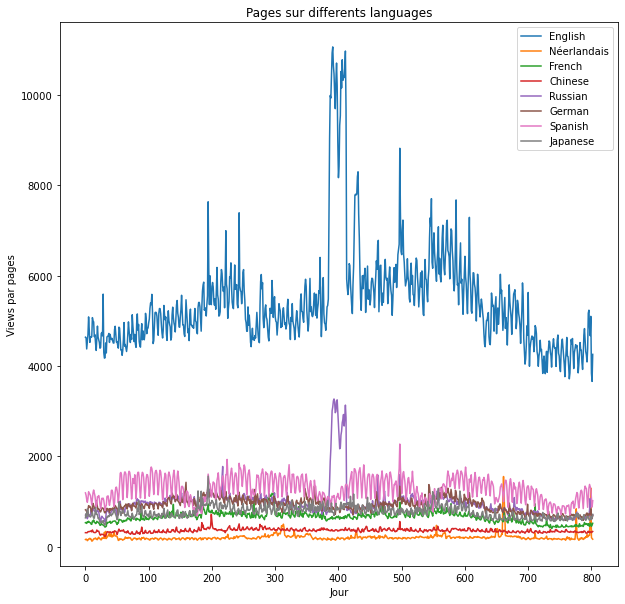

```python
### Creer un dataset par rapport language
lang_data = {}
lang_data['en'] = train[train.Language=='en'].iloc[:,0:-1]
lang_data['na'] = train[train.Language=='na'].iloc[:,0:-1]
lang_data['fr'] = train[train.Language=='fr'].iloc[:,0:-1]
lang_data['zh'] = train[train.Language=='zh'].iloc[:,0:-1]
lang_data['ru'] = train[train.Language=='ru'].iloc[:,0:-1]
lang_data['de'] = train[train.Language=='de'].iloc[:,0:-1]
lang_data['es'] = train[train.Language=='es'].iloc[:,0:-1]
lang_data['ja'] = train[train.Language=='ja'].iloc[:,0:-1]

sums = {}
for key in lang_data:
    sums[key] = lang_data[key].iloc[:,1:-3].sum(axis=0) / lang_data[key].shape[0]

### Plot sur le nbre de views par pages par rapport a chaque language

jours = [r for r in range(sums["en"].shape[0])]

fig = plt.figure(1,figsize=[10,10])
plt.ylabel('Views par pages')
plt.xlabel('Jour')
plt.title('Pages sur differents languages')
labels={'en':'English','ja':'Japanese','de':'German',
        'na':'Néerlandais','fr':'French','zh':'Chinese',
        'ru':'Russian','es':'Spanish',
       }

for key in sums:
    plt.plot(jours,sums[key],label = labels[key] )

plt.legend()
plt.show()
```

**Commentaire :** Prédominance de l'anglais, suivi de l'espagnol. Pour des raisons de curiosité et d'intérêts, nous décidons de nous focaliser uniquement sur **l'anglais**, l'**allemand**, le **chinois** et le **français**.

# Création d'une variable explicative supplémentaire : le thème de l'article

Pour classer les articles, nous utiliserons le modèle NLP "zero-shot-classification, facebook/bart-large-mnli", qui est un modèle de pointe basé sur un transformateur entraîné sur un grand ensemble de données en langage naturel. Ce modèle est conçu pour obtenir de bonnes performances dans un large éventail de tâches NLP, notamment la classification, la traduction et le résumé.

L'une des principales caractéristiques du modèle "zero-shot-classification, facebook/bart-large-mnli" est sa capacité à effectuer une classification "zero-shot", ce qui signifie qu'il peut classer des documents dans des catégories qu'il n'a pas vues pendant la formation. Cela est possible grâce à l'utilisation d'une représentation partagée du texte qui permet au modèle de transférer des connaissances provenant d'autres tâches et d'autres langues.

Nous nous concentrons sur les données en anglais.

```python
#Voici comment nous avons créé notre dataset des articles en anglais avec le thème du sujet qu'ils traite.
#Code à ne pas faire tourner, tant la durée de compilation est grande.
train_en = lang_data["en"]
classifier = pipeline("zero-shot-classification",
                      model="facebook/bart-large-mnli")

#Obtenir le titre des articles
def get_title(page):
    pos1 = page.rindex("_en.")
    pos2 = page[:pos1]
    return pos2

articles_name = train_en.Page.map(get_title)
candidate_labels = ["Mathematics and abstractions", "Art and culture", "Geography and places", "Health and fitness", "History and events", "Natural sciences and nature",
                    "People and self", "Philosophy and thinking", "Religion and spirituality", "Social sciences and society", "Technology and applied sciences"]
category = []
for i, name in enumerate(articles_name):
    sequence_to_classify = name
    scores = classifier(sequence_to_classify, candidate_labels)['scores']
    labels =  classifier(sequence_to_classify, candidate_labels)['labels']
    max_value = max(scores)
    index = scores.index(max_value)
    category.append(labels[index])

train_category = train_en[0:i]
train_category['category'] =  category
train_category.to_csv("train_category.csv")
```

```python
topics = pd.read_csv('train_category.csv')

print("Shape des données:",topics.shape)
def get_title(page):
    pos1 = page.rindex("_en.")
    pos2 = page[:pos1]
    return pos2

topics_dict = {}
topics_dict['en'] = topics
articles_name = topics_dict['en'].Page.map(get_title)

topics['Page'] = articles_name
topics['Page']

topics[['Page', 'category']].tail(5)
topics.to_csv("Wikipedia_topics.csv")
```

```
Shape des données: (1705, 806)
```

##### Exemples

```python
topics[topics['category']=='Mathematics and abstractions'][['Page', 'category']]
```

|  | Page | category |
| --- | --- | --- |
| 136 | Algebraic_topology | Mathematics and abstractions |
| 384 | Calc | Mathematics and abstractions |
| 385 | Calculator | Mathematics and abstractions |
| 710 | Ex_Machina_(film) | Mathematics and abstractions |
| 739 | Fermat's_Last_Theorem | Mathematics and abstractions |
| 744 | Fibonacci_number | Mathematics and abstractions |
| 931 | Hetalia:_Axis_Powers | Mathematics and abstractions |
| 1406 | MF_Grimm | Mathematics and abstractions |

Les classifications semblent assez cohérentes.

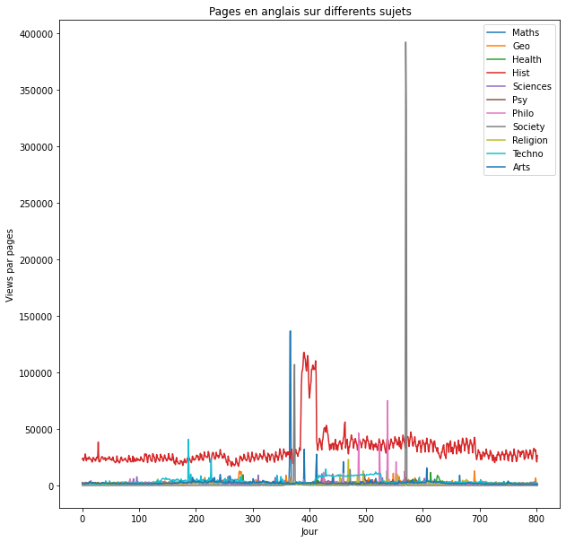

```python
topic_sets = {}
topic_sets['Mathematics and abstractions'] = topics[topics['category']=='Mathematics and abstractions'].iloc[:,0:-1]
topic_sets['Geography and places'] = topics[topics['category']=='Geography and places'].iloc[:,0:-1]
topic_sets['Health and fitness'] = topics[topics['category']=='Health and fitness'].iloc[:,0:-1]
topic_sets['History and events'] = topics[topics['category']=='History and events'].iloc[:,0:-1]
topic_sets['Natural sciences and nature'] = topics[topics['category']=='Natural sciences and nature'].iloc[:,0:-1]
topic_sets['People and self'] = topics[topics['category']=='People and self'].iloc[:,0:-1]
topic_sets['Philosophy and thinking'] = topics[topics['category']=='Philosophy and thinking'].iloc[:,0:-1]
topic_sets['Social sciences and society'] = topics[topics['category']=='Social sciences and society'].iloc[:,0:-1]
topic_sets['Religion and spirituality'] = topics[topics['category']=='Religion and spirituality'].iloc[:,0:-1]
topic_sets['Technology and applied sciences'] = topics[topics['category']=='Technology and applied sciences'].iloc[:,0:-1]
topic_sets['Art and culture'] = topics[topics['category']=='Art and culture'].iloc[:,0:-1]


sums = {}
for key in topic_sets:
    sums[key] = topic_sets[key].iloc[:,2:].sum(axis=0) / topic_sets[key].shape[0]

jours = [r for r in range(sums["Mathematics and abstractions"].shape[0])]


fig = plt.figure(1,figsize=[10,10])
plt.ylabel('Views par pages')
plt.xlabel('Jour')
plt.title('Pages en anglais sur differents sujets')
labels={"Mathematics and abstractions" : "Maths", "Art and culture": "Arts", "Geography and places":"Geo",
        "Health and fitness": "Health", "History and events":"Hist", "Natural sciences and nature":"Sciences",
        "People and self":"Psy", "Philosophy and thinking":"Philo", "Religion and spirituality":"Religion",
        "Social sciences and society":"Society", "Technology and applied sciences":"Techno"
       }

for key in sums:
    plt.plot(jours,sums[key],label = labels[key] )

plt.legend()
plt.show()
```

Compte tenu de la quantité de données et des variations qui apparaissent, il est difficile d'observer des tendances significatives. Il semble toutefois que les opinions varient de façon assez constante selon le sujet, avec des pics en mathématiques, en Histoire, en Sujets de société.

Nous aimerions évaluer les performances du modèle à l'aide de diverses métriques et de l'ajuster pour améliorer sa précision, mais par manque de temps, nous en restons à cette approximation. Dans l'ensemble, cette initiative nous montrera la puissance du traitement automatique des langues et de l'apprentissage automatique pour automatiser le processus de catégorisation des données textuelles et extraire des informations utiles de grands volumes d'informations non structurées.

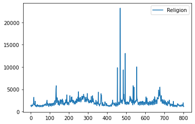

```python
plt.plot(jours,topic_sets['Religion and spirituality'].iloc[:,2:].sum(axis=0) / topic_sets['Religion and spirituality'].shape[0],label = 'Religion' )
plt.legend()
plt.show()
```

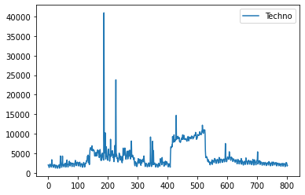

```python
plt.plot(jours,topic_sets['Technology and applied sciences'].iloc[:,2:].sum(axis=0) / topic_sets['Technology and applied sciences'].shape[0],label = 'Techno' )
plt.legend()
plt.show()
```

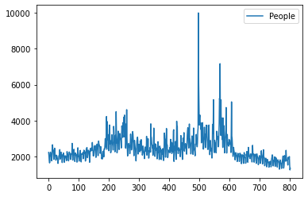

```python
plt.plot(jours,topic_sets['People and self'].iloc[:,2:].sum(axis=0) / topic_sets['People and self'].shape[0],label = 'People' )
plt.legend()
plt.show()
```

À noter que les petits traffics également connaissent des pics.

# ARIMA sur le traffic des pages par rapport à language utilisée (Anglais, Allemand, Francais, Chinois)

ARIMA, ou "Auto Regressive Integrated Moving Average", est une classe de modèles qui "explique" une série chronologique donnée sur la base de ses propres valeurs passées, c'est-à-dire ses propres retards et les erreurs de prévision retardées, de sorte que l'équation peut être utilisée pour prévoir les valeurs futures.

Toute série temporelle "non saisonnière" qui présente des caractéristiques et qui n'est pas un bruit blanc aléatoire peut être modélisée par des modèles ARIMA.

Un modèle ARIMA est caractérisé par 3 termes : p, d, q où

- p est l'ordre du terme AR
- q est l'ordre du terme MA
- d est le nombre de différenciations nécessaires pour rendre la série temporelle stationnaire.

### Modèle AR

Un modèle autorégressif (AR seulement) est un modèle où $Y_t$ ne dépend que de ses propres retards. Autrement dit, $Y_t$ est une fonction des "retards de $Y_t$"

$Y_t=\alpha+\beta_1Y_{t-1}+\beta_2Y_{t-2}+..+\beta_pY_{t-p}+\epsilon_1$

où $Y_{t-1}$ est le lag1 de la série, $\beta_1$ est le coefficient du lag1 que le modèle estime et $\alpha$ est le terme d'interception, également estimé par le modèle.

### Modèle MA

De même, un modèle MA est un modèle où $Y_t$ ne dépend que des erreurs de prévision retardées.

$Y_t=\alpha+\epsilon_t+\phi_1\epsilon_{t-1}+\phi_2\epsilon_{t-2}+..+\phi_q\epsilon_{t-q}$

où les termes d'erreur sont les erreurs des modèles autorégressifs des retards respectifs. Les erreurs $\epsilon_t$ et $\epsilon_{t-1}$ sont les erreurs des équations suivantes :

$Y_t=\beta_1Y_{t-1}+\beta_2Y_{t-2}+..+\beta_0Y_{0}+\epsilon_t$

$Y_{t-1}=\beta_1Y_{t-2}+\beta_2Y_{t-3}+..+\beta_0Y_{0}+\epsilon_{t-1}$

### Modèle ARIMA

Un modèle ARIMA est un modèle où la série temporelle a été différenciée au moins une fois pour la rendre stationnaire et où l'on combine les termes AR et MA. L'équation devient donc :

$Y_t=\alpha+\beta_1Y_{t-1}+\beta_2Y_{t-2}+..+\beta_pY_{t-p}\epsilon_t+\phi_1\epsilon_{t -1}+\phi_2\epsilon_{t-2}+..+\phi_q\epsilon_{t-q}$

### Résumé des étapes à faire

Voici le résumé des étapes que nous allons suivre pour en implémenter un :

1. Rendre la série stationnaire en supprimant la Trend et la Saisonalité. Cela se fait en prenant la différence dans les données où en faisant une transformaiton comme un log ou une racine carrée.
2. Identifier l'ordre du modèle ARIMA (p,d,q) en examinant l'autocorrélation. Le terme "p" représente l'odre du composant autoregressif (AR), "d" l'odre de la différence, et "q" celui de la moyenne mobile (MA).
3. Ajuster le modèle à la série temporelle et l'utiliser pour faire des prédictions.
4. Évaluer le modèle et la précision de la prédiction.

### **Étape 1: Verifier la stationnarite**

L'un des facteurs les plus importants que on doit prendre en compte lors de l'application du modèle ARIMA aux séries temporelles est que les données qu'on utilise doit être stationnaires.

```python
#View par chaque language chaque jour a partir de 1/7/2015 au 10/09/2017

total_view = {}
for key in lang_data:
    total_view[key] = lang_data[key].iloc[:, 1:-3].sum(axis=0) / len(lang_data[key])

data_en = total_view['en'] #View des pages en Anglais
data_de = total_view['de'] #View des pages en Allemagne
data_fr = total_view['fr'] #View des pages en Francais
data_ch = total_view['zh'] #View des pages en Chinois
```

##### Test ADF

Test ADF est un test statistique qui vise à savoir si une série temporelle est stationnaire c'est-à-dire si ses propriétés statistiques (espérance, variance, auto-corrélation) varient ou pas dans le temps.

```python
def adf_test(x, name):
    dfoutput = pd.DataFrame(columns=['Test Statistic','p-value','#Lags Used','Number of Observations Used','Critical Value (1%)', 'Critical Value (5%)','Critical Value (10%)','Name'])
    for i in range(len(x)):
        dftest = adfuller(x[i], autolag='AIC')
        dfoutput.loc[i]=[dftest[0],dftest[1],dftest[2],dftest[3], dftest[4]['1%'], dftest[4]['5%'], dftest[4]['10%'],name[i]]
    return dfoutput
```

**Rappel :** pour le test ADF

Hypothèse nulle (HO) : la série est non stationnaire

Hypothèse alternative (H1): La série est stationnaire

```python
adf_test([data_en, data_de, data_fr, data_ch],['anglais','allemand','français','chinois'])
```

|  | Test Statistic | p-value | #Lags Used | Number of Observations Used | Critical Value (1%) | Critical Value (5%) | Critical Value (10%) | Name |
| --- | --- | --- | --- | --- | --- | --- | --- | --- |
| 0 | -3.396666 | 0.011073 | 21 | 781 | -3.438751 | -2.865248 | -2.568744 | anglais |
| 1 | -1.590738 | 0.488244 | 21 | 781 | -3.438751 | -2.865248 | -2.568744 | allemand |
| 2 | -1.715705 | 0.423040 | 20 | 782 | -3.438740 | -2.865243 | -2.568742 | français |
| 3 | -2.837007 | 0.053179 | 21 | 781 | -3.438751 | -2.865248 | -2.568744 | chinois |

##### **Test stationnarite pour les pages en Anglais**

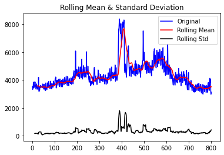

```python
def test_stationarity(x):


    #Determing rolling statistics
    rolmean = x.rolling(window=22,center=False).mean()

    rolstd = x.rolling(window=12,center=False).std()

    #Plot rolling statistics:
    orig = plt.plot(x.values, color='blue',label='Original')
    mean = plt.plot(rolmean.values, color='red', label='Rolling Mean')
    std = plt.plot(rolstd.values, color='black', label = 'Rolling Std')
    plt.legend(loc='best')
    plt.title('Rolling Mean & Standard Deviation')
    plt.show()
test_stationarity(data_en)
```

On trouve que pour les Pages en Anglais, le graphique de Rolling Mean et de Rolling Std n'est pas constant, ce qui corrobore l'hypothèse selon laquelle ces donnees ne sont pas stationnaires.

**Allemand**

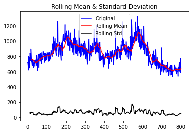

```python
test_stationarity(data_de)
```

Dans ce cas, pareil on trouve que pour les Pages en Allemagne, le graphique de Rolling Mean et de Rolling Std n'est pas constant, ce qui montre que ces donnees ne sont pas stationnaires.

**Francais**

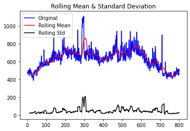

```python
test_stationarity(data_fr)
```

Pareil comme les 2 premiers, les donnees sur les pages en Francais ne sont pas stationnaires

**Chinois**

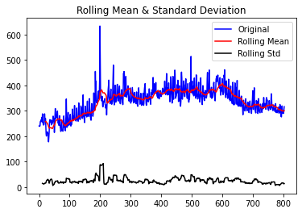

```python
test_stationarity(data_ch)
```

De même résultat, les données sur les pages en Chinois ne sont pas stationnaires

##### **KPSS Test**

L'exécution à la fois du test de Dickey-Fuller (ADF) et du test de Kwiatkowski-Phillips-Schmidt-Shin (KPSS) lors de l'évaluation de la stationnarité peut fournir une évaluation plus complète des données et peut aider à confirmer ou à réfuter nos résultats.

Le test KPSS est également un test de racine unitaire, mais il est utilisé pour déterminer si la série est stationnaire en tendance, ce qui signifie qu'elle est stationnaire autour d'une tendance déterministe. L'hypothèse nulle H0 du test KPSS est "La série est stationnaire en tendance", tandis que l'hypothèse alternative H1 est "La série n'est pas stationnaire en tendance".

En effectuant les deux tests, on peut obtenir une perception plus complète de la stationnarité des données. Par exemple, si le test ADF suggère que les données sont stationnaires et que le test KPSS suggère que les données ne sont pas stationnaires en tendance, cela peut indiquer que les données sont stationnaires mais présentent un autre type de non-stationnarité, comme des fluctuations périodiques ou saisonnières. Dans de tels cas, une analyse plus approfondie peut être nécessaire pour comprendre la nature de la non-stationnarité et déterminer le plan d'action approprié.

Hypothèse nulle (HO) : la série est stationnaire en tendance

Hypothèse alternative (H1): La série est non stationnaire en tendance

```python
def kpss_test(x, name):
    kpss_output = pd.DataFrame(columns=['Test Statistic','p-value','#Lags Used','Critical Value (1%)', 'Critical Value (5%)','Critical Value (10%)','Name'])
    for i in range(len(x)):
        kpsstest = kpss(x[i], regression='c', nlags="auto")
        kpss_output.loc[i]=[kpsstest[0],kpsstest[1],kpsstest[2],kpsstest[3]['1%'], kpsstest[3]['5%'], kpsstest[3]['10%'],name[i]]
    return kpss_output
```

```python
kpss_test([data_en, data_de, data_fr, data_ch],['anglais','allemand','français','chinois'])
```

|  | Test Statistic | p-value | #Lags Used | Critical Value (1%) | Critical Value (5%) | Critical Value (10%) | Name |
| --- | --- | --- | --- | --- | --- | --- | --- |
| 0 | 0.576517 | 0.024771 | 17 | 0.739 | 0.463 | 0.347 | anglais |
| 1 | 1.259470 | 0.010000 | 17 | 0.739 | 0.463 | 0.347 | allemand |
| 2 | 1.060942 | 0.010000 | 17 | 0.739 | 0.463 | 0.347 | français |
| 3 | 0.784973 | 0.010000 | 15 | 0.739 | 0.463 | 0.347 | chinois |

**Anglais :** Statistique de test > valeur critique et p-value < 0,05. En conséquence, nous rejetons l'hypothèse nulle au profit d'une alternative donc non stationnaire

Il en va de même pour l'Allemand, le français et le chinois.

#### L'ordre de différenciation (d) dans le modèle ARIMA

On utilise la différenciation. Plus précisément, on va trouver le nombre de différenciations nécessaire pour que notre série soit stationnaire.

##### **Pour les pages en Anglais**

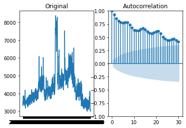

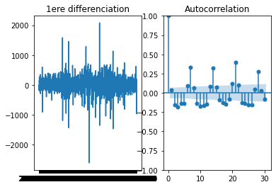

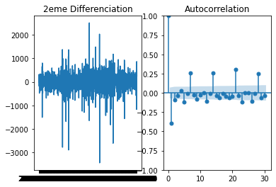

```python
#original
fig, (ax1, ax2) = plt.subplots(1, 2)
ax1.plot(data_en)
ax1.set_title('Original')
plot_acf(data_en, ax=ax2)
plt.show()

#1ere differenciation
fig, (ax1, ax2) = plt.subplots(1, 2)
ax1.plot(data_en.diff())
ax1.set_title('1ere differenciation')
plot_acf(data_en.diff().dropna(), ax=ax2)
plt.show()

#2eme Differenciation
fig, (ax1, ax2) = plt.subplots(1, 2)
ax1.plot(data_en.diff().diff())
ax1.set_title('2eme Differenciation')
plot_acf(data_en.diff().diff().dropna(), ax=ax2)
plt.show()
```

Pour la 1ere differentiation, la série temporelle atteint la stationnarité avec deux ordres de différentiation. Mais en regardant le graphique d'autocorrélation pour la deuxième différenciation, le lag passe assez rapidement dans la zone négative, ce qui indique que la série a peut-être été surdifférenciée. Donc on choisit la 1ere differentiation (d=1)

```python
adf_test([data_en.diff().dropna()], ['anglais'])
```

|  | Test Statistic | p-value | #Lags Used | Number of Observations Used | Critical Value (1%) | Critical Value (5%) | Critical Value (10%) | Name |
| --- | --- | --- | --- | --- | --- | --- | --- | --- |
| 0 | -5.622507 | 0.000001 | 21 | 780 | -3.438761 | -2.865253 | -2.568747 | anglais |

Le p-value obtenue est inférieure au niveau de signification de 0,05 et la statistique ADF est inférieure à toutes les valeurs critiques. Donc, on a le droit de rejeter l'hypothèse nulle. Ainsi, la série temporelle devient bien stationnaire.

```python
kpss_test([data_en.diff().dropna()], ['anglais'])
```

|  | Test Statistic | p-value | #Lags Used | Critical Value (1%) | Critical Value (5%) | Critical Value (10%) | Name |
| --- | --- | --- | --- | --- | --- | --- | --- |
| 0 | 0.155914 | 0.1 | 81 | 0.739 | 0.463 | 0.347 | anglais |

Test statistique < valeur critique et p-valeur > 0,05. En conséquence, nous acceptons l'hypothèse nulle en faveur d'une alternative. Nous concluons donc que la série est stationnaire

##### **ALLEMAND**

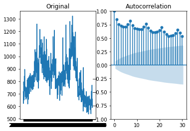

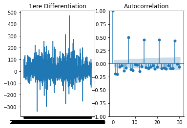

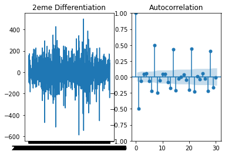

```python
#original
from statsmodels.graphics.tsaplots import plot_acf, plot_pacf
fig, (ax1, ax2) = plt.subplots(1, 2)
ax1.plot(data_de)
ax1.set_title('Original')
plot_acf(data_de, ax=ax2)

#1ère différenciation
fig, (ax1, ax2) = plt.subplots(1, 2)
ax1.plot(data_de.diff())
ax1.set_title('1ere Differentiation')
plot_acf(data_de.diff().dropna(), ax=ax2)


#2nd Differencing
fig, (ax1, ax2) = plt.subplots(1, 2)
ax1.plot(data_de.diff().diff())
ax1.set_title('2eme Differentiation')
plot_acf(data_de.diff().diff().dropna(), ax=ax2)
plt.show()
```

On voit que le lag de la 2eme différentiation passe plus vite au zone de négatif que la 1ere donc la 1ere différentiation a l'air plus intéressant que la 2eme

```python
#adf test
adf_test([data_de.diff().dropna()], ["Allemand"])
```

|  | Test Statistic | p-value | #Lags Used | Number of Observations Used | Critical Value (1%) | Critical Value (5%) | Critical Value (10%) | Name |
| --- | --- | --- | --- | --- | --- | --- | --- | --- |
| 0 | -6.816164 | 2.056611e-09 | 20 | 781 | -3.438751 | -2.865248 | -2.568744 | Allemand |

Le p-value obtenue est inférieure au niveau de signification de 0,05 et la statistique ADF est inférieure à toutes les valeurs critiques. Donc, on a le droit de rejeter l'hypothèse nulle. Ainsi, la série temporelle est stationnaire.

```python
kpss_test([data_de.diff().dropna()], ["Allemand"])
```

|  | Test Statistic | p-value | #Lags Used | Critical Value (1%) | Critical Value (5%) | Critical Value (10%) | Name |
| --- | --- | --- | --- | --- | --- | --- | --- |
| 0 | 0.5 | 0.041667 | 801 | 0.739 | 0.463 | 0.347 | Allemand |

Test statistique < valeur critique de 1% et p-valeur > 0,01. En conséquence, nous acceptons l'hypothèse nulle en faveur d'une alternative. Nous concluons donc que la série est stationnaire

##### **FRANCAIS**

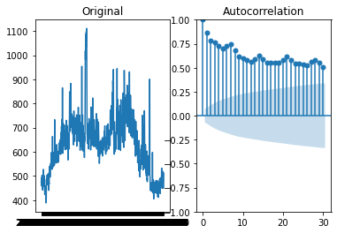

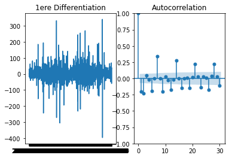

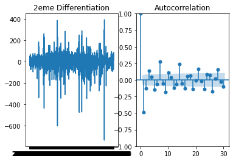

```python
#Original
fig, (ax1, ax2) = plt.subplots(1, 2)
ax1.plot(data_fr)
ax1.set_title('Original')
plot_acf(data_fr, ax=ax2)

#1st Differencing
fig, (ax1, ax2) = plt.subplots(1, 2)
ax1.plot(data_fr.diff())
ax1.set_title('1ere Differentiation')
plot_acf(data_fr.diff().dropna(), ax=ax2)

#2nd Differencing
fig, (ax1, ax2) = plt.subplots(1, 2)
ax1.plot(data_fr.diff().diff())
ax1.set_title('2eme Differentiation')
plot_acf(data_fr.diff().diff().dropna(), ax=ax2)
plt.show()
```

On voit que le lag de la 2eme différentiation passe plus vite au zone de négatif que la 1ere donc la 1ere différentiation a l'air plus intéressant que la 2eme

```python
#adf test
adf_test([data_fr.diff().dropna()], ['Français'])
```

|  | Test Statistic | p-value | #Lags Used | Number of Observations Used | Critical Value (1%) | Critical Value (5%) | Critical Value (10%) | Name |
| --- | --- | --- | --- | --- | --- | --- | --- | --- |
| 0 | -10.150972 | 7.953073e-18 | 18 | 783 | -3.438729 | -2.865238 | -2.568739 | Français |

Le p-value obtenue est inférieure au niveau de signification de 0,05 et la statistique ADF est inférieure à toutes les valeurs critiques. Donc, on a le droit de rejeter l'hypothèse nulle. Ainsi, la série temporelle est stationnaire.

```python
#kpss test
kpss_test([data_fr.diff().dropna()], ['Français'])
```

|  | Test Statistic | p-value | #Lags Used | Critical Value (1%) | Critical Value (5%) | Critical Value (10%) | Name |
| --- | --- | --- | --- | --- | --- | --- | --- |
| 0 | 0.119903 | 0.1 | 36 | 0.739 | 0.463 | 0.347 | Français |

Test statistique < tous les valeurs critiques et p-valeur > 0,05. En conséquence, nous acceptons l'hypothèse nulle en faveur d'une alternative. Nous concluons donc que la série est stationnaire

##### **CHINOIS**

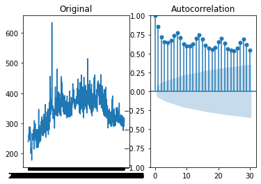

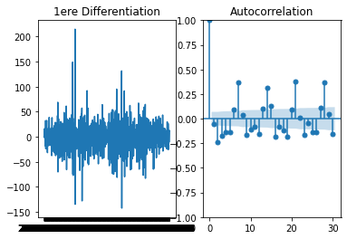

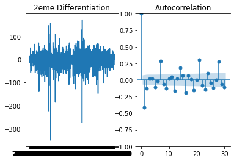

```python
fig, (ax1, ax2) = plt.subplots(1, 2)
ax1.plot(data_ch)
ax1.set_title('Original')
plot_acf(data_ch, ax=ax2)

#1st Differencing
fig, (ax1, ax2) = plt.subplots(1, 2)
ax1.plot(data_ch.diff())
ax1.set_title('1ere Differentiation')
plot_acf(data_ch.diff().dropna(), ax=ax2)


#2nd Differencing
fig, (ax1, ax2) = plt.subplots(1, 2)
ax1.plot(data_ch.diff().diff())
ax1.set_title('2eme Differentiation')
plot_acf(data_ch.diff().diff().dropna(), ax=ax2)
plt.show()
```

On voit que le lag de la 2eme différentiation passe plus vite au zone de négatif que la 1ere donc la 1ere différentiation a l'air plus intéressant que la 2eme

```python
#adf test
adf_test([data_ch.diff().dropna()], ["Chinois"])
```

|  | Test Statistic | p-value | #Lags Used | Number of Observations Used | Critical Value (1%) | Critical Value (5%) | Critical Value (10%) | Name |
| --- | --- | --- | --- | --- | --- | --- | --- | --- |
| 0 | -8.047897 | 1.774123e-12 | 21 | 780 | -3.438761 | -2.865253 | -2.568747 | Chinois |

Le p-value obtenue est inférieure au niveau de signification de 0,05 et la statistique ADF est inférieure à toutes les valeurs critiques. Donc, on a le droit de rejeter l'hypothèse nulle. Ainsi, la série temporelle est stationnaire.

```python
#kpss test
kpss_test([data_ch.diff().dropna()], ["Chinois"])
```

|  | Test Statistic | p-value | #Lags Used | Critical Value (1%) | Critical Value (5%) | Critical Value (10%) | Name |
| --- | --- | --- | --- | --- | --- | --- | --- |
| 0 | 0.206512 | 0.1 | 68 | 0.739 | 0.463 | 0.347 | Chinois |

Test statistique < tous les valeurs critiques et p-valeur > 0,05. En conséquence, nous acceptons l'hypothèse nulle en faveur d'une alternative. Nous concluons donc que la série est stationnaire

**Conclusion:** Avec toutes les differents langues, on a besoin d'une première différentiation pour les mettre stationnaire

### Trouver l'ordre du terme AR (p) et le terme MA (q)

On peut déterminer le nombre requis de termes AR en inspectant le graphique d'autocorrélation partielle (PACF). Toute autocorrélation dans une série stationnarisée peut être rectifiée en ajoutant suffisamment de termes AR. Ainsi, on prend initialement l'ordre du terme AR comme étant égal à autant de 'lag' que le nombre de 'lag' qui franchit la limite de signification dans le graphique PACF.

Partial autocorrelation of lag(k) d'une série est le coefficient de ce décalage dans l'équation d'autorégression de Y

$Y_t = \alpha_0+\alpha_1Y_{t-1}+\alpha_2Y_{t-2}+\alpha_3Y_{t-3}$

Autrement dit, si $Y_t$ est la série en ce moment et $Y_{t-1}$ est le lag 1 de Y, alors l'autocorrélation partielle du lag 3 $Y_{t-3}$ est le coefficient $\alpha_3$ de $Y_{t-3}$ dans l'équation ci-dessus. Toute autocorrélation dans une série stationnarisée peut être rectifiée en ajoutant suffisamment de termes AR. Ainsi, on prend initialement l'ordre du terme AR comme étant égal à autant de décalages que le nombre de décalages qui franchit la limite de signification dans le graphique PACF.

Comme le graphique PACF pour le nombre de termes AR, on peut vérifier le graphique ACF pour le nombre de termes MA. Un terme MA est techniquement, l'erreur de la prévision 'lag'. L'ACF indique combien de termes MA sont nécessaires pour éliminer toute autocorrélation dans la série stationnarisée.

##### Anglais

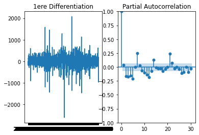

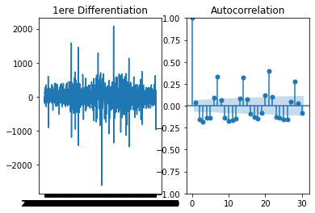

```python
fig, (ax1, ax2) = plt.subplots(1, 2)
ax1.plot(data_en.diff())
ax1.set_title('1ere Differentiation')
plot_pacf(data_en.diff().dropna(), ax=ax2)
plt.show()

fig, (ax1, ax2) = plt.subplots(1, 2)
ax1.plot(data_en.diff())
ax1.set_title('1ere Differentiation')
plot_acf(data_en.diff().dropna(), ax=ax2)
plt.show()
```

##### Allemand

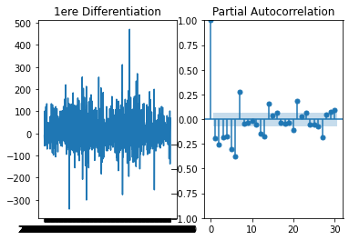

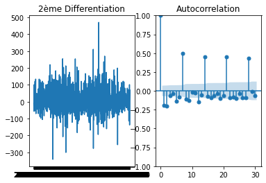

```python
fig, (ax1, ax2) = plt.subplots(1, 2)
ax1.plot(data_de.diff())
ax1.set_title('1ere Differentiation')
plot_pacf(data_de.diff().dropna(), ax=ax2)


fig, (ax1, ax2) = plt.subplots(1, 2)
ax1.plot(data_de.diff())
ax1.set_title('2ème Differentiation')
plot_acf(data_de.diff().dropna(), ax=ax2)
plt.show()
```

##### Français

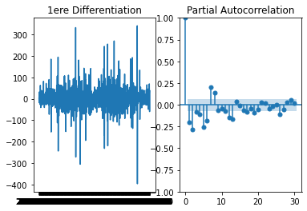

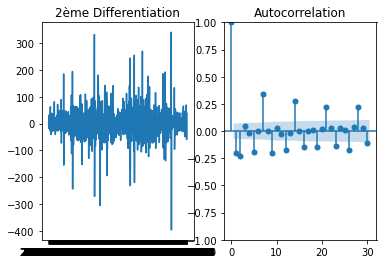

```python
fig, (ax1, ax2) = plt.subplots(1, 2)
ax1.plot(data_fr.diff())
ax1.set_title('1ere Differentiation')
plot_pacf(data_fr.diff().dropna(), ax=ax2)

fig, (ax1, ax2) = plt.subplots(1, 2)
ax1.plot(data_fr.diff())
ax1.set_title('2ème Differentiation')
plot_acf(data_fr.diff().dropna(), ax=ax2)
plt.show()
```

##### Chinois

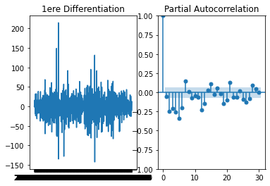

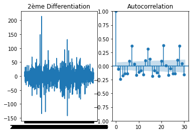

```python
fig, (ax1, ax2) = plt.subplots(1, 2)
ax1.plot(data_ch.diff())
ax1.set_title('1ere Differentiation')
plot_pacf(data_ch.diff().dropna(), ax=ax2)

fig, (ax1, ax2) = plt.subplots(1, 2)
ax1.plot(data_ch.diff())
ax1.set_title('2ème Differentiation')
plot_acf(data_ch.diff().dropna(), ax=ax2)
plt.show()
```